# OOI Stacked Plot for Oceanographic Data

Liz Ferguson, eferguson@oceanscienceanalytics.com

Last updated: 8/18/2022

This notebook provides you with an example of how to create a stacked plot of oceanographic data variables in R. The specific data used in this example come from the Ocean Observatories Intiative’s suite of oceanographic data off of Newport, Oregon (Cabled Endurance Array), and were queried using the Data Explorer and exported into csv format.

## Loading Packages & Data

First you will load (after installing locally) the following packages:

```r
#Suggest add by Denisse
library(lubridate) #Library to deal with datetime data
```

Next we will load in the data for each of the four variables (note: download all four csv files from and set working directory locally when on your own computer!). We will then need to use the as.POSIXct function to convert the date/time into a format that allows you to display along the x-axis.

** Denisse comment: Personally, I think it is better to work with a Project, this way you can provide relative paths and share your work a lot easier with others. **

1. Start first with the temperature..

| Date | Time | Date_Time | sea_water_temp_degC |
| --- | --- | --- | --- |
| 2018-04-01 | 00:00:00 | 2018-04-01 00:00:00 | 4.539036 |
| 2018-04-01 | 00:01:00 | 2018-04-01 00:01:00 | 4.539906 |
| 2018-04-01 | 00:02:00 | 2018-04-01 00:02:00 | 4.540946 |
| 2018-04-01 | 00:03:00 | 2018-04-01 00:03:00 | 4.541845 |
| 2018-04-01 | 00:04:00 | 2018-04-01 00:04:00 | 4.542764 |
| 2018-04-01 | 00:05:00 | 2018-04-01 00:05:00 | 4.543157 |
| 2018-04-01 | 00:06:00 | 2018-04-01 00:06:00 | 4.544206 |
| 2018-04-01 | 00:07:00 | 2018-04-01 00:07:00 | 4.544729 |
| 2018-04-01 | 00:08:00 | 2018-04-01 00:08:00 | 4.544949 |
| 2018-04-01 | 00:09:00 | 2018-04-01 00:09:00 | 4.544998 |

[output cut: 990 more lines]

2. Next we add in partial pressure of CO2:

| Date | Time | Date_Time | pp_CO2 |
| --- | --- | --- | --- |
| 2018-04-01 | 00:05:00 | 2018-04-01 00:05:00 | 1076.0651 |
| 2018-04-01 | 01:05:00 | 2018-04-01 01:05:00 | 1080.9510 |
| 2018-04-01 | 02:05:00 | 2018-04-01 02:05:00 | 1084.5134 |
| 2018-04-01 | 03:05:00 | 2018-04-01 03:05:00 | 1080.7975 |
| 2018-04-01 | 04:05:00 | 2018-04-01 04:05:00 | 1080.1091 |
| 2018-04-01 | 05:05:00 | 2018-04-01 05:05:00 | 1092.3258 |
| 2018-04-01 | 06:05:00 | 2018-04-01 06:05:00 | 1092.2957 |
| 2018-04-01 | 07:05:00 | 2018-04-01 07:05:00 | 1089.7400 |
| 2018-04-01 | 08:05:00 | 2018-04-01 08:05:00 | 1086.3522 |
| 2018-04-01 | 09:05:00 | 2018-04-01 09:05:00 | 1082.1306 |

[output cut: 659 more lines]

3. And the salinity:

| Date | Time | Date_Time | Salinity_0.001 |
| --- | --- | --- | --- |
| 2018-04-01 | 00:00:00 | 2018-04-01 00:00:00 | 33.95302 |
| 2018-04-01 | 00:01:00 | 2018-04-01 00:01:00 | 33.95261 |
| 2018-04-01 | 00:02:00 | 2018-04-01 00:02:00 | 33.95257 |
| 2018-04-01 | 00:03:00 | 2018-04-01 00:03:00 | 33.95230 |
| 2018-04-01 | 00:04:00 | 2018-04-01 00:04:00 | 33.95201 |
| 2018-04-01 | 00:05:00 | 2018-04-01 00:05:00 | 33.95159 |
| 2018-04-01 | 00:06:00 | 2018-04-01 00:06:00 | 33.95251 |
| 2018-04-01 | 00:07:00 | 2018-04-01 00:07:00 | 33.95172 |
| 2018-04-01 | 00:08:00 | 2018-04-01 00:08:00 | 33.95153 |
| 2018-04-01 | 00:09:00 | 2018-04-01 00:09:00 | 33.95154 |

[output cut: 990 more lines]

4. And finally the dissolved oxygen data:

| Date | Time | Date_Time | DO |
| --- | --- | --- | --- |
| 2018-04-01 | 00:00:00 | 2018-04-01 00:00:00 | 13.62545 |
| 2018-04-01 | 00:01:00 | 2018-04-01 00:01:00 | 13.68060 |
| 2018-04-01 | 00:02:00 | 2018-04-01 00:02:00 | 13.70785 |
| 2018-04-01 | 00:03:00 | 2018-04-01 00:03:00 | 13.74062 |
| 2018-04-01 | 00:04:00 | 2018-04-01 00:04:00 | 13.76838 |
| 2018-04-01 | 00:05:00 | 2018-04-01 00:05:00 | 13.80637 |
| 2018-04-01 | 00:06:00 | 2018-04-01 00:06:00 | 13.83098 |
| 2018-04-01 | 00:07:00 | 2018-04-01 00:07:00 | 13.86138 |
| 2018-04-01 | 00:08:00 | 2018-04-01 00:08:00 | 13.87542 |
| 2018-04-01 | 00:09:00 | 2018-04-01 00:09:00 | 13.89090 |

[output cut: 990 more lines]

## Plotting the Data

We will create each of the line graph figures separately:

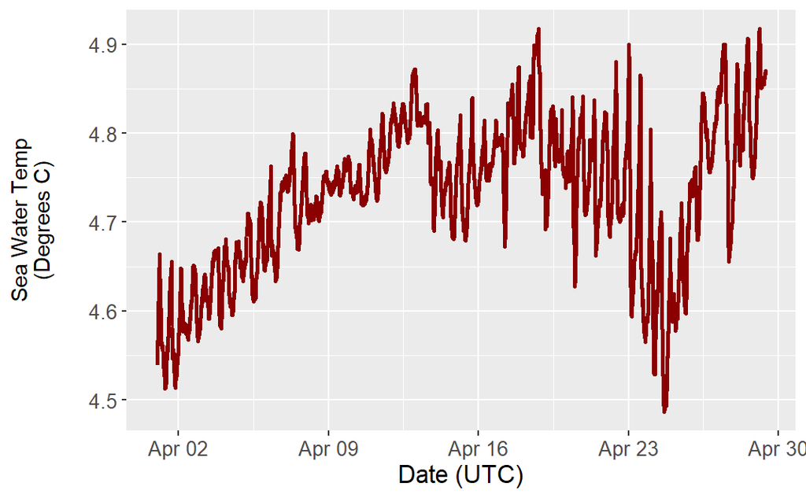

2. Partial pressure of CO2

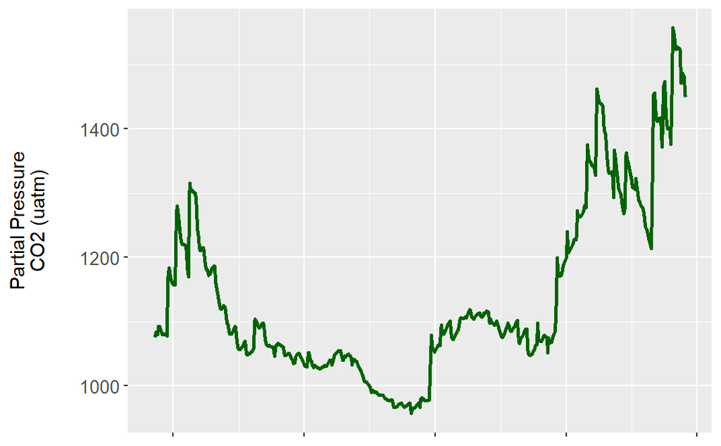

3. Salinity

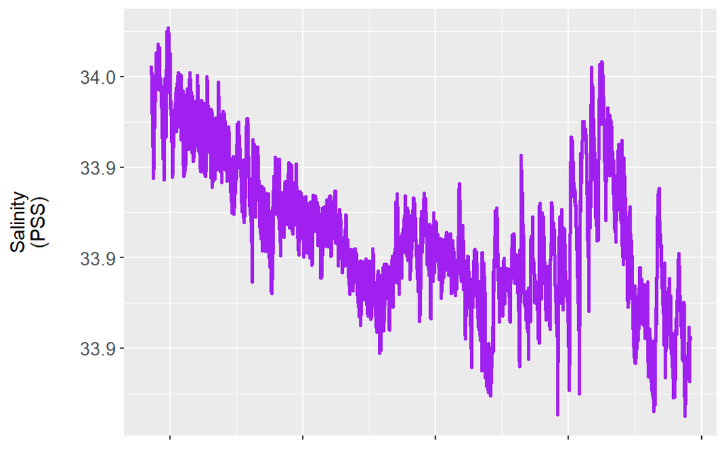

4. Dissolved Oxygen

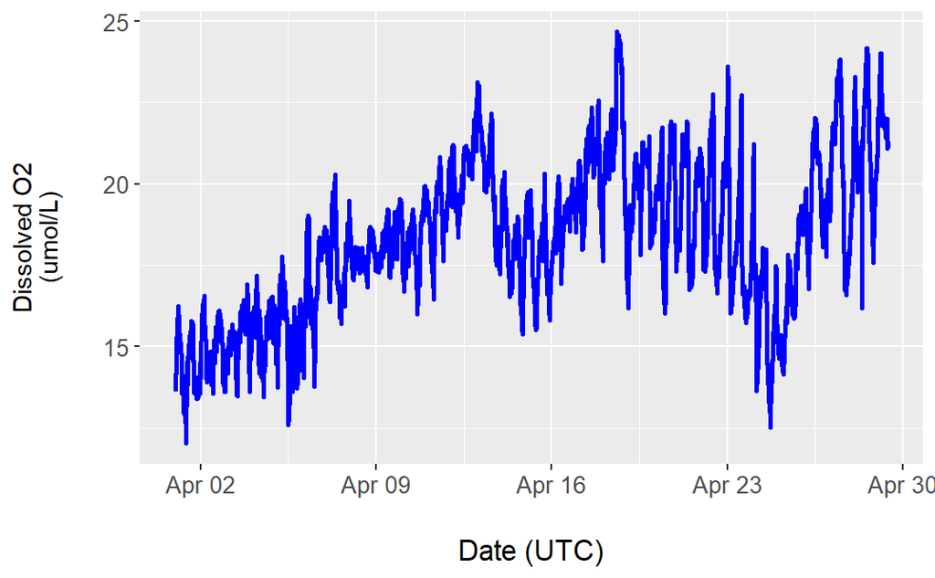